# Analiza korespondencji

Adam Michalski

```r
suppressWarnings(library(readr))
poeci <- read_csv2("poeci.csv", col_names = FALSE, locale = locale(encoding = "Windows-1250"), col_types = cols(
  X1 = col_factor(), X2 = col_factor())
  )
```

```
## ℹ Using "','" as decimal and "'.'" as grouping mark. Use `read_delim()` for more control.
```

```r
colnames(poeci) <- c("Miasto", "Poeta")
summary(poeci)
```

```
##       Miasto          Poeta
##  Łódź    :56   Szymborska:73
##  Warszawa:68   Herbert   :63
##  Gdańsk  :35   Różewicz  :55
##  Kraków  :48   Miłosz    :59
##  Wrocław :43
```

```r
dane <- table(poeci)
str(dane)
```

```
##  'table' int [1:5, 1:4] 14 14 10 18 17 17 15 14 8 9 ...
##  - attr(*, "dimnames")=List of 2
##   ..$ Miasto: chr [1:5] "Łódź" "Warszawa" "Gdańsk" "Kraków" ...
##   ..$ Poeta : chr [1:4] "Szymborska" "Herbert" "Różewicz" "Miłosz"
```

Skłonność do grupowania danych zilustrujemy w oparciu o mapy ciepła:

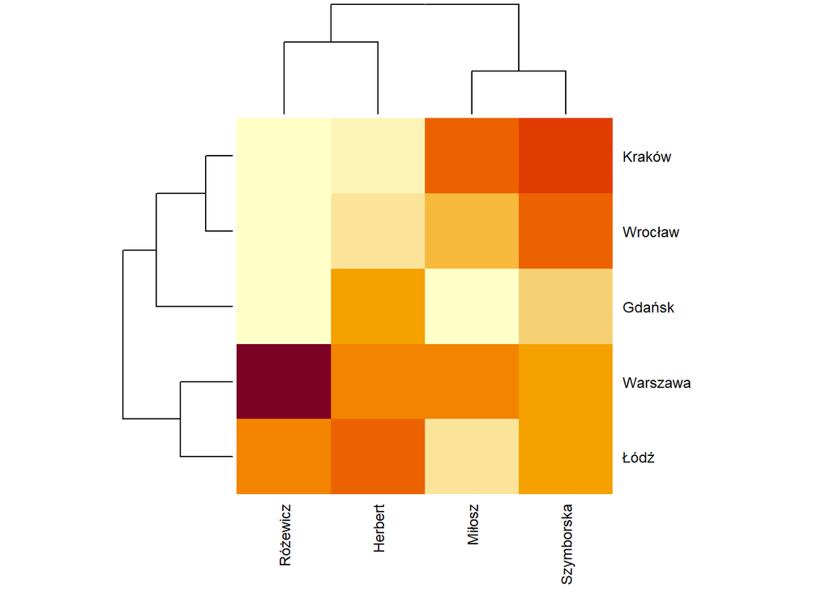

```r
heatmap(dane, scale = "none", cexRow = 0.9, cexCol = 0.9)
```

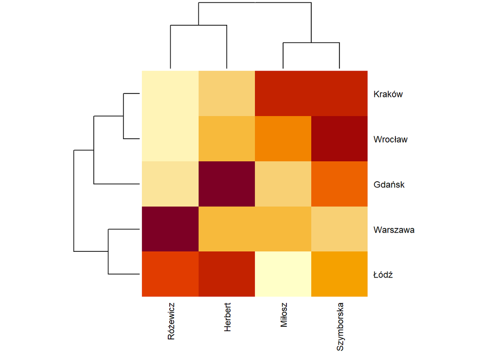

```r
heatmap(dane, scale="row", cexRow = 0.9, cexCol = 0.9)
```

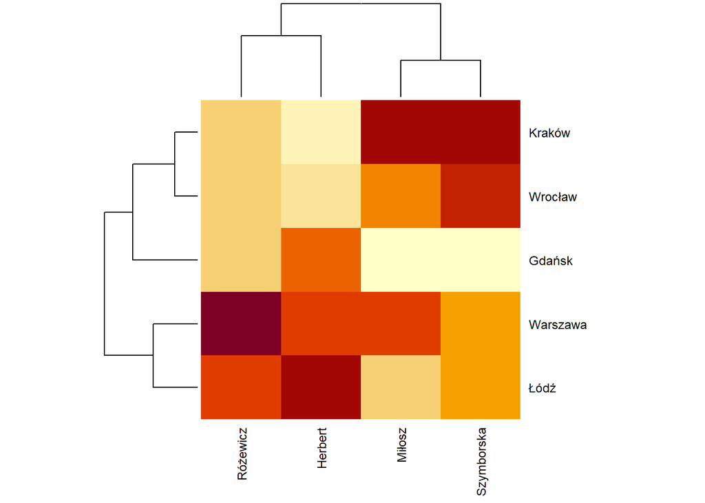

```r
heatmap(dane, scale="col", cexRow = 0.9, cexCol = 0.9)
```

Na początek stworzymy tabelę korespondencji:

```r
n <- sum(dane)
P <- dane/n
str(P)
```

```
##  'table' num [1:5, 1:4] 0.056 0.056 0.04 0.072 0.068 0.068 0.06 0.056 0.032 0.036 ...
##  - attr(*, "dimnames")=List of 2
##   ..$ Miasto: chr [1:5] "Łódź" "Warszawa" "Gdańsk" "Kraków" ...
##   ..$ Poeta : chr [1:4] "Szymborska" "Herbert" "Różewicz" "Miłosz"
```

Następnie obliczymy częstości brzegowe zwane w analizie korespondencji masami wierszy i kolumn:

```r
masa_w <- rowSums(P)
masa_w
```

```
##     Łódź Warszawa   Gdańsk   Kraków  Wrocław
##    0.224    0.272    0.140    0.192    0.172
```

```r
masa_k <- colSums(P)
masa_k
```

```
## Szymborska    Herbert   Różewicz     Miłosz
##      0.292      0.252      0.220      0.236
```

Wyznaczamy dalej teoretyczne częstości łączne, których oczekiwalibyśmy w przypadku całkowitej niezależności:

```r
teor <- outer(masa_w, masa_k, "*")
str(teor)
```

```
##  num [1:5, 1:4] 0.0654 0.0794 0.0409 0.0561 0.0502 ...
##  - attr(*, "dimnames")=List of 2
##   ..$ : chr [1:5] "Łódź" "Warszawa" "Gdańsk" "Kraków" ...
##   ..$ : chr [1:4] "Szymborska" "Herbert" "Różewicz" "Miłosz"
```

Na koniec wyznaczymy standaryzowane reszty pearsonowskie niosące informacje o odchyłkach od niezależności danych:

```r
E <- (P-teor)/teor^(1/2)
str(E)
```

```
##  'table' num [1:5, 1:4] -0.03679 -0.08312 -0.00435 0.0673 0.07932 ...
##  - attr(*, "dimnames")=List of 2
##   ..$ Miasto: chr [1:5] "Łódź" "Warszawa" "Gdańsk" "Kraków" ...
##   ..$ Poeta : chr [1:4] "Szymborska" "Herbert" "Różewicz" "Miłosz"
```

Zauważmy, że otrzymujemy poniżej ręcznie wyznaczoną wartość będącą wynikiem testu niezależności $\chi^2$

```r
n*sum(E*E)
```

```
## [1] 28.12152
```

```r
test <- chisq.test(dane)
test
```

```
##
##  Pearson's Chi-squared test
##
## data:  dane
## X-squared = 28.122, df = 12, p-value = 0.00531
```

Mapy ciepła odchyłek od niezależności wyglądają następująco:

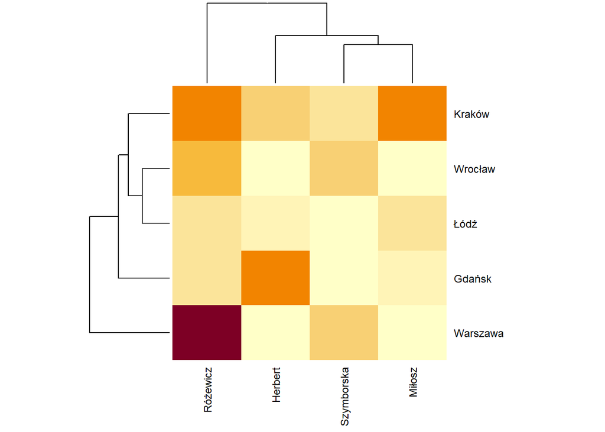

```r
heatmap(E*E, scale = "none", cexRow = 0.9, cexCol = 0.9)
```

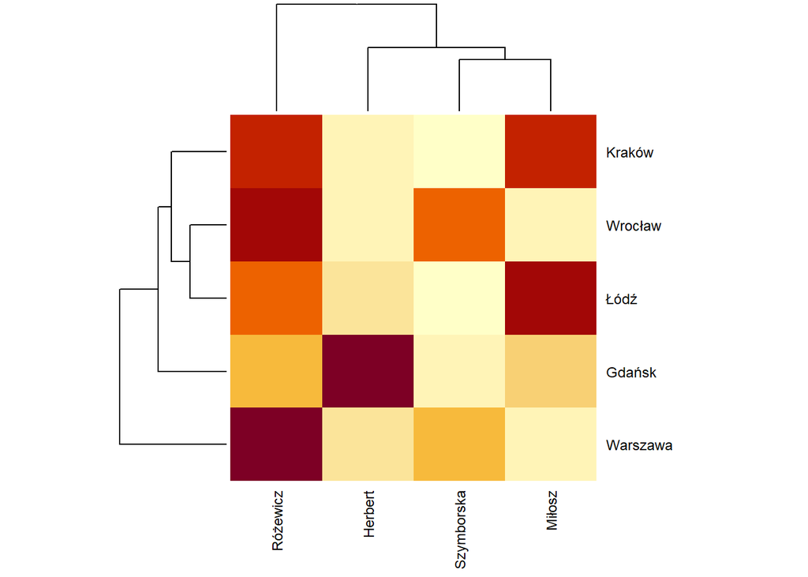

```r
heatmap(E*E, scale="row", cexRow = 0.9, cexCol = 0.9)
```

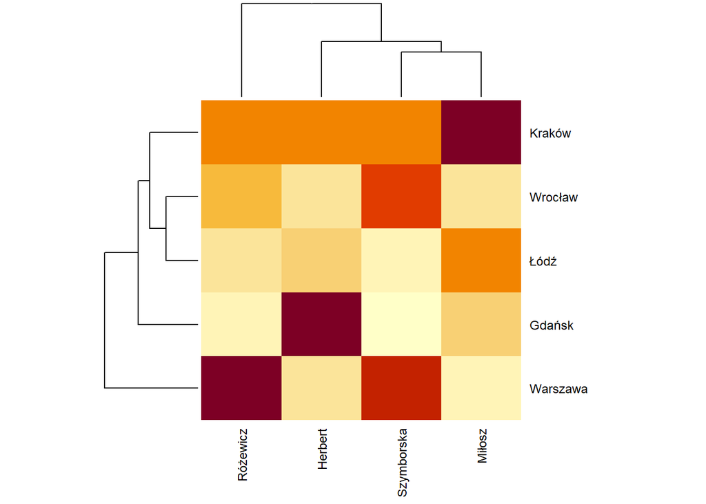

```r
heatmap(E*E, scale="col", cexRow = 0.9, cexCol = 0.9)
```

Skoro odrzuciliśmy hipotezę o niezależności w następnej kolejności spróbujemy ustalić postać zależności między miastem studiowania, a wyborem ulubionego poety.

```r
S <- svd(E)
str(S)
```

```
## List of 3
##  $ d: num [1:4] 2.84e-01 1.74e-01 4.08e-02 1.75e-17
##  $ u: num [1:5, 1:4] -0.38153 -0.52334 -0.00778 0.61158 0.45438 ...
##  $ v: num [1:4, 1:4] 0.475 -0.2253 -0.7403 0.4191 0.0686 ...
```

Korzystając z powyższej dekompozycji macierzy $E\cdot E^T$ standaryzując współrzędne wierszy i kolumn(poprzez dzielenie ich przez pierwiastki z odpowiednich częstości brzegowych) otrzymujemy następujący wykres zwany mapą percepcji:

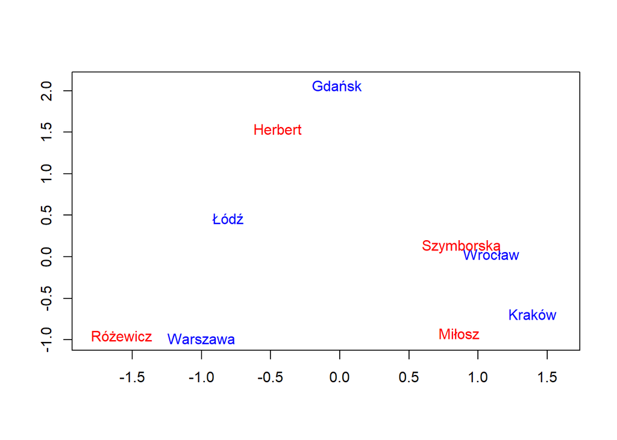

```r
X <- diag(1/sqrt(masa_w)) %*% S$u
Y <- diag(1/sqrt(masa_k)) %*% S$v
plot(rbind(X[,1:2], Y[,1:2]), col = "white", xlab = "", ylab = "", main = "", xlim = c(-1.8, 1.6), ylim = c(-1, 2.1))
text(X[,1:2], levels(poeci$Miasto), col = "blue")
text(Y[,1:2], levels(poeci$Poeta), col = "red")
```

Na podstawie własnego wykresu widać, że Tadeusz Różewicz jest najpopularniejszy wśród studentów Warszawy, pośród studentów Wrocławia i Krakowa dominują Wisława Szymborska i Czesław Miłosz, w Gdańsku cieszy się popularnością Zbigniew Herbert, a w Łodzi opinie o ulubionym poecie zdają się być podzielone. Analogiczny wykres tworzy pakiet ca:

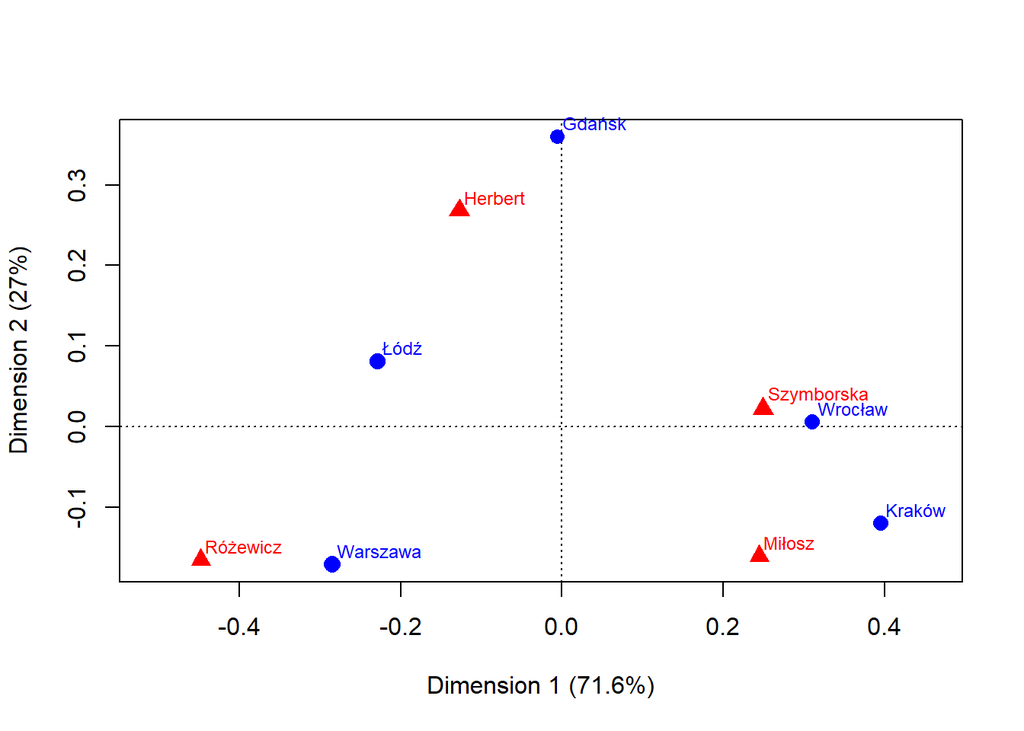

```r
library(ca)
plot(ca(dane), mass=T)
```

```r
library(readr)
hobbies <- read_csv2("hobbies.csv",
                     locale = locale(encoding = "Windows-1250"), col_types = cols_only(Reading = col_factor(),
                                                                                       Sex = col_factor(),
                                                                                       Age = col_factor(),
                                                                                       Profession = col_factor()))
```

```
## ℹ Using "','" as decimal and "'.'" as grouping mark. Use `read_delim()` for more control.
```

```r
levels(hobbies$Reading) <- c("Yes", "No")
colnames(hobbies)[colnames(hobbies) == "Sex"] <- "Gender"
summary(hobbies)
```

```
##  Reading    Gender        Age                  Profession
##  Yes:5646   F:4616   (45,55]:1837   Employee        :2552
##  No :2757   M:3787   (35,45]:1646   Manual labourer :1161
##                      (25,35]:1302   Management      :1052
##                      (55,65]:1257   Unskilled worker: 792
##                      (65,75]: 937   Foreman         : 735
##                      [15,25]: 857   (Other)         : 613
##                      (Other): 567   NA's            :1498
```

```r
colSums(is.na(hobbies))
```

```
##    Reading     Gender        Age Profession
##          0          0          0       1498
```

```r
levels(hobbies$Profession) <- c(levels(hobbies$Profession), "Other")
#Kod do zastępowania braków we wszystkich kolumnach:
#hobbies[] <- lapply(hobbies, function(x) replace(x, is.na(x), "Other"))
hobbies$Profession <- replace(hobbies$Profession, is.na(hobbies$Profession), "Other")
colSums(is.na(hobbies))
```

```
##    Reading     Gender        Age Profession
##          0          0          0          0
```

```r
hobbies_reading <- subset(hobbies, Reading == "Yes", select = -c(Reading))
dane_reading <- table(hobbies_reading)
str(dane_reading)
```

```
##  'table' int [1:2, 1:8, 1:7] 59 118 96 119 79 79 15 29 87 109 ...
##  - attr(*, "dimnames")=List of 3
##   ..$ Gender    : chr [1:2] "F" "M"
##   ..$ Age       : chr [1:8] "(55,65]" "(45,55]" "(25,35]" "(75,85]" ...
##   ..$ Profession: chr [1:7] "Management" "Employee" "Manual labourer" "Foreman" ...
```

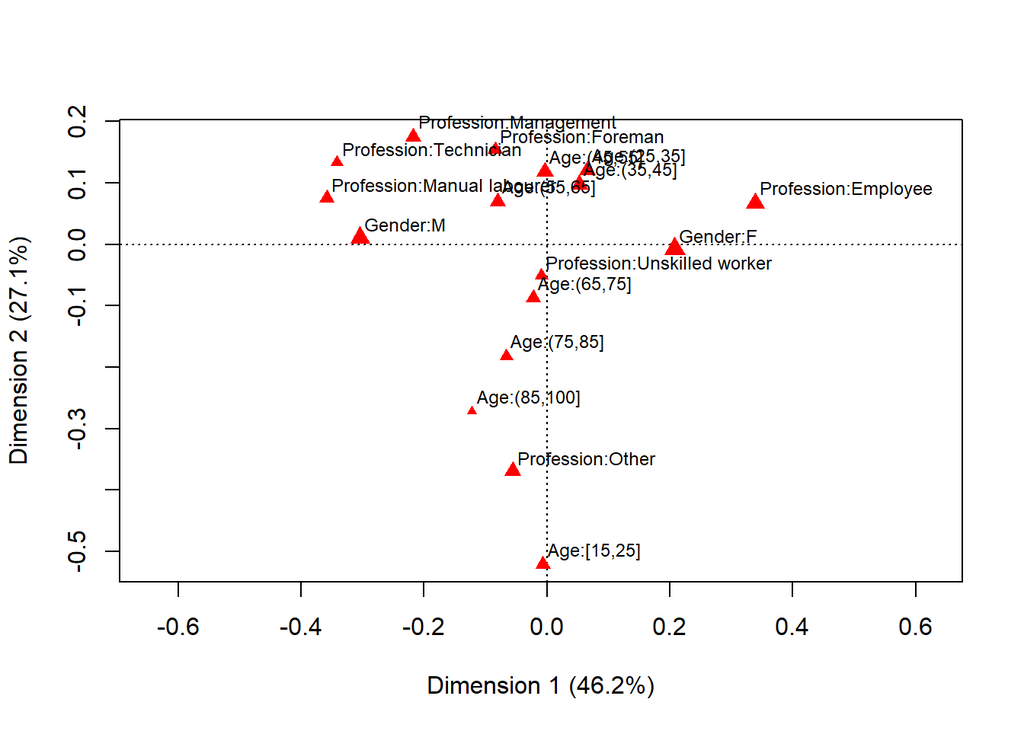

```r
library(ca)
suppressWarnings(plot(mjca(dane_reading), mass = c(T, T)))
```

Z wykresu rzeczywiście niewiele widać, więc przeprowadzimy dalej analizę korespondencji dla wszystkich par kolumn.

```r
suppressWarnings(library(gtools))

column_combinations <- combinations(ncol(hobbies_reading), 2, colnames(hobbies_reading))

hobbies_pairs <- list()
dane_pairs <- list()
labels_pairs <- list()

for (i in 1:nrow(column_combinations)) {
  hobbies_pairs[[i]] <- hobbies_reading[, column_combinations[i, ]]
  dane_pairs[[i]] <- table(hobbies_pairs[[i]])
  labels_pairs[[i]] <- c(column_combinations[i, 1], column_combinations[i, 2])
}
summary(hobbies_pairs[[1]])
```

```
##       Age       Gender
##  (45,55]:1228   F:3354
##  (35,45]:1123   M:2292
##  (25,35]: 893
##  (55,65]: 824
##  (65,75]: 627
##  [15,25]: 550
##  (Other): 401
```

Skłonność do grupowania poszczególnych par danych zilustrujemy w oparciu o mapy ciepła:

```
## Para kolumn Age & Gender :
```

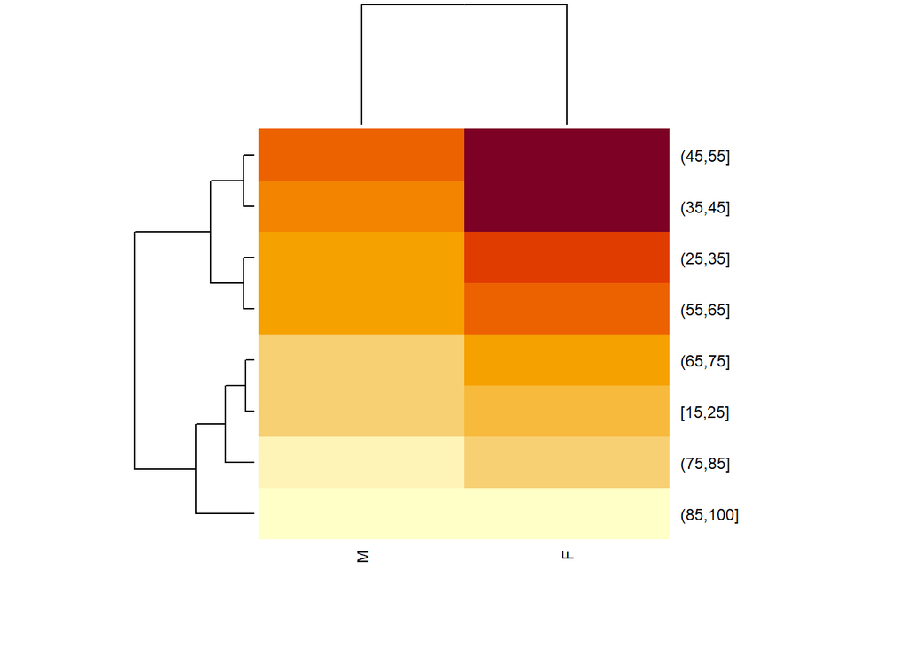

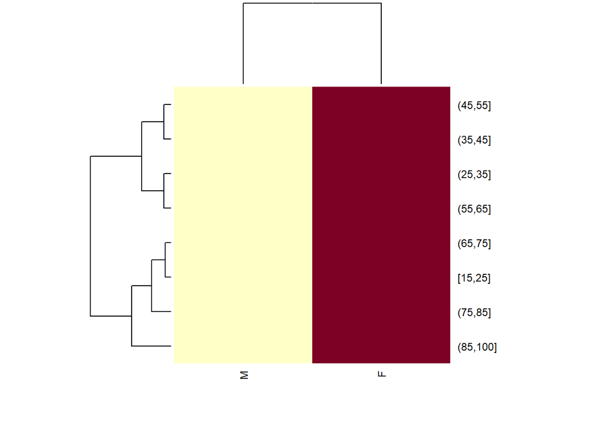

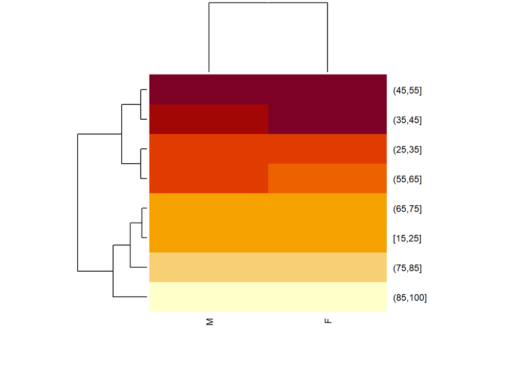

```
## Para kolumn Age & Profession :
```

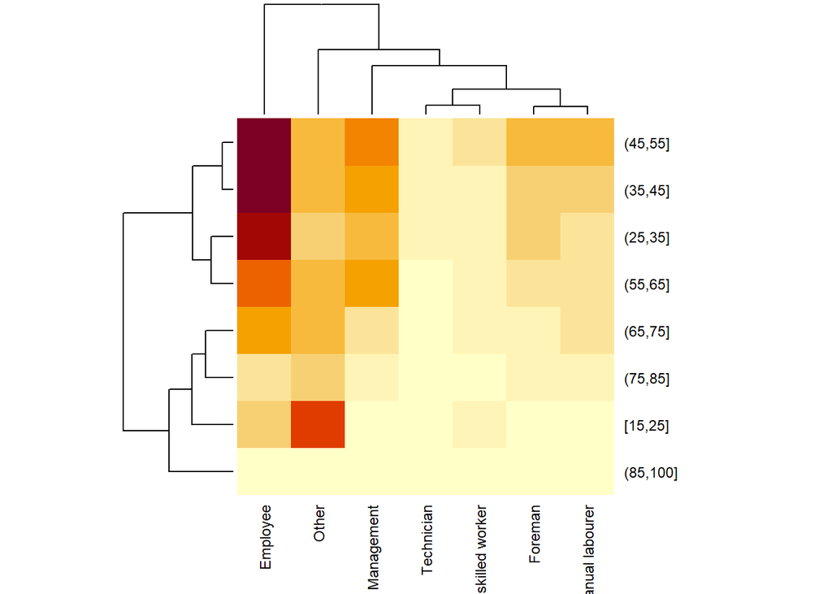

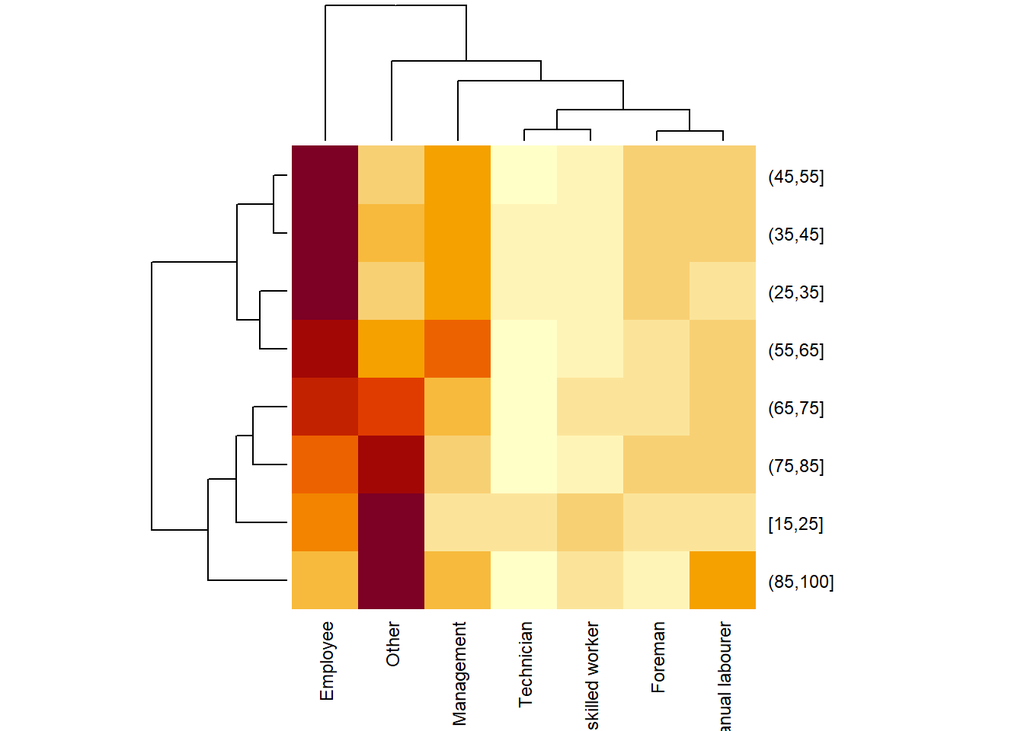

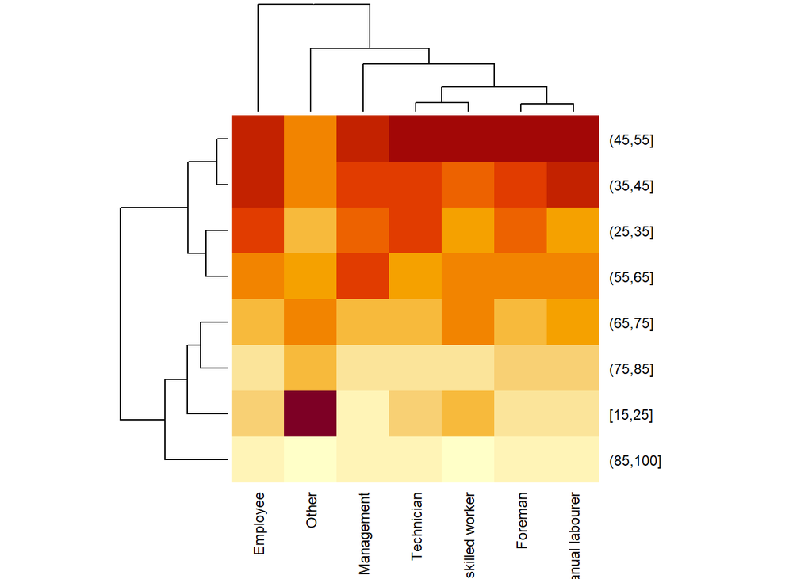

```
## Para kolumn Gender & Profession :
```

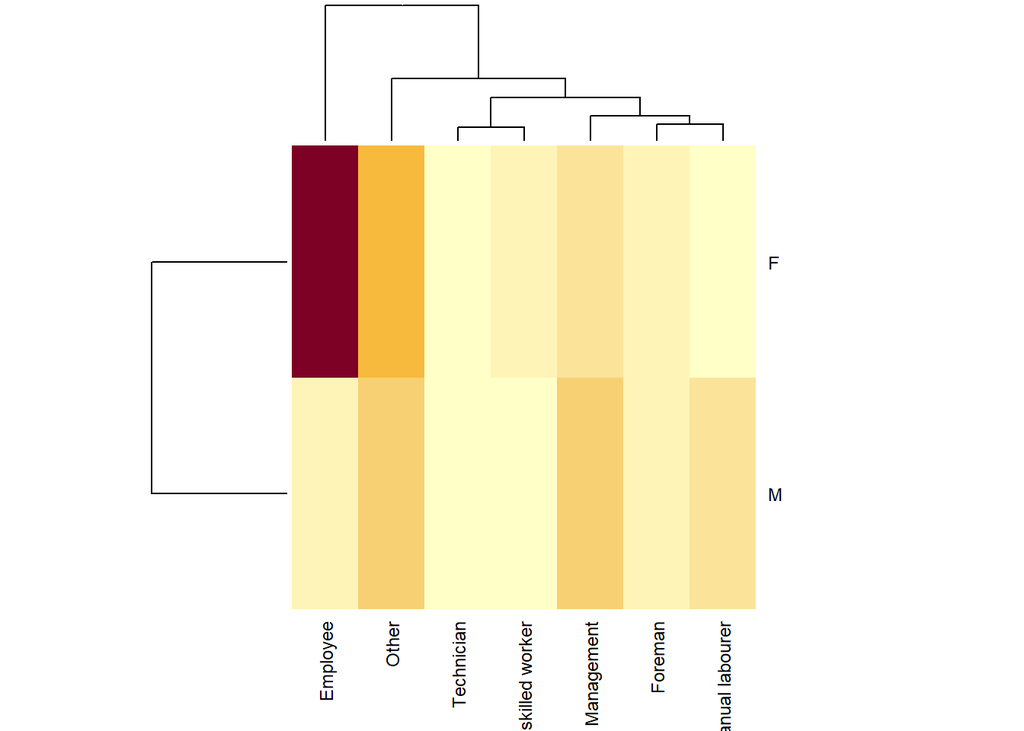

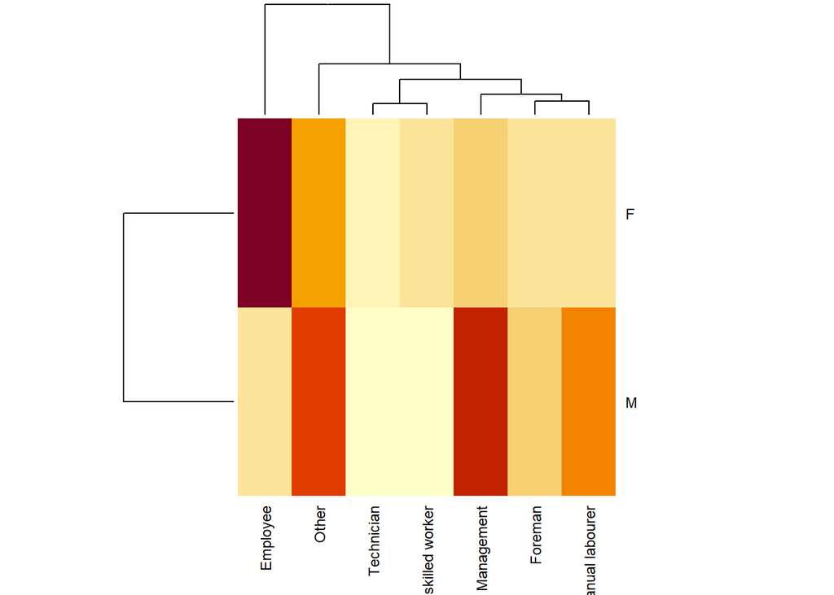

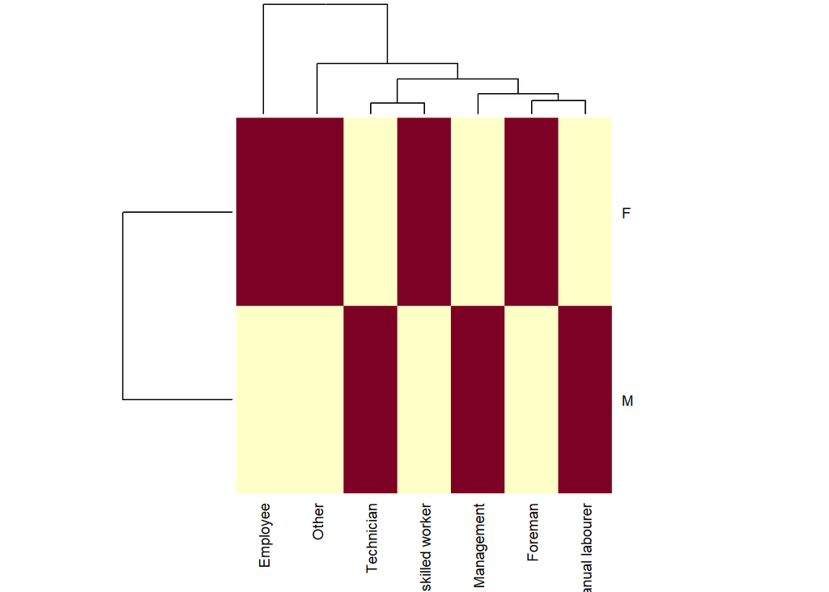

```r
for (i in 1:length(hobbies_pairs)) {
  cat("Para kolumn", labels_pairs[[i]][1], "&", labels_pairs[[i]][2], ":")
  heatmap(dane_pairs[[i]], scale = "none", cexRow = 0.9, cexCol = 0.9)


  heatmap(dane_pairs[[i]], scale="row", cexRow = 0.9, cexCol = 0.9)


  heatmap(dane_pairs[[i]], scale="col", cexRow = 0.9, cexCol = 0.9)
}
```

Dla każdej z par możemy utworzyć własną mapę percepcji:

```
## Para kolumn Age & Gender :
## p-value testu na niezależność 0.383849
```

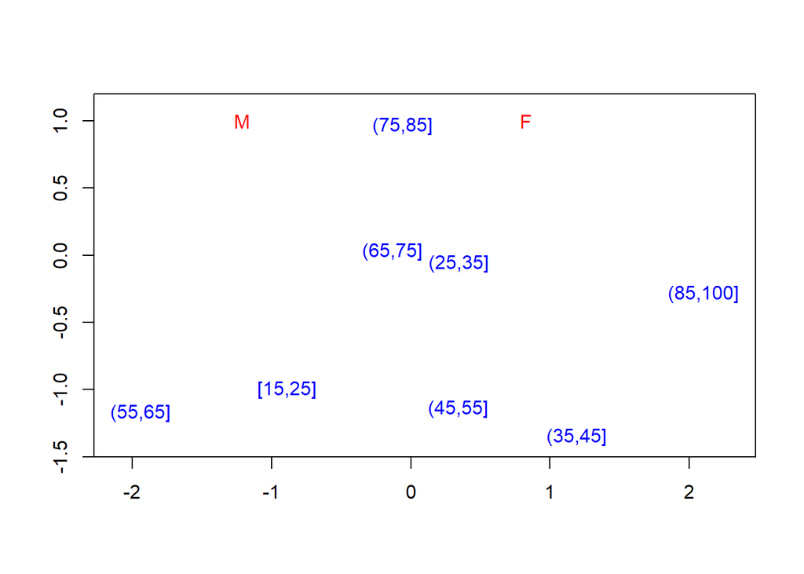

```
## Para kolumn Age & Profession :
## p-value testu na niezależność 0
```

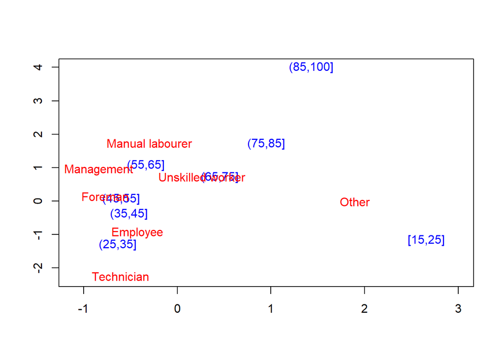

```
## Para kolumn Gender & Profession :
## p-value testu na niezależność 0
```

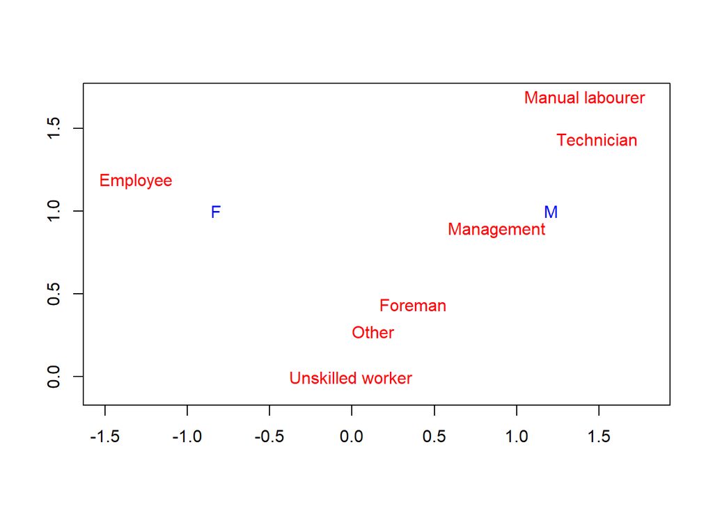

```r
xlims <- list(c(-2.1, 2.3), c(-1.1, 3), c(-1.5, 1.8))
ylims <- list(c(-1.4, 1.1), c(-2.3, 4), c(-0.1, 1.7))
for (i in 1:length(hobbies_pairs)) {
  cat("Para kolumn", labels_pairs[[i]][1], "&", labels_pairs[[i]][2], ":\n")
  n <- sum(dane_pairs[[i]])
  P <- dane_pairs[[i]]/n
  masa_w <- rowSums(P)
  masa_k <- colSums(P)
  teor <- outer(masa_w, masa_k, "*")
  E <- (P-teor)/teor^(1/2)
  chi_squared_stat <- n * sum(E*E)
  df <- (nrow(dane_pairs[[i]]) - 1) * (ncol(dane_pairs[[i]]) - 1)
  p_value <- 1 - pchisq(chi_squared_stat, df)
  cat("p-value testu na niezależność", p_value)
  S <- svd(E)
  X <- diag(1/sqrt(masa_w)) %*% S$u
  Y <- diag(1/sqrt(masa_k)) %*% S$v
  plot(rbind(X[,1:2], Y[,1:2]), col = "white", xlab = "", ylab = "", main = "", xlim = xlims[[i]], ylim = ylims[[i]])
  text(X[,1:2], levels(hobbies_reading[[labels_pairs[[i]][1]]]), col = "blue")
  text(Y[,1:2], levels(hobbies_reading[[labels_pairs[[i]][2]]]), col = "red")
}
```

Ponieważ p wartość testu $\chi^2$ niezależności wynosi 0.38 na żadnym sensownym poziomie istotności nie mamy podstaw do odrzucenia hipotezy o niezależności wieku od płci pośród osób czytających (można też podejrzewać brak silnej zależności na podstawie mapy percepcji. Na podstawie map percepcji dla pozostałych kolumn o p wartościach testu $\chi^2$ niezależności bliskich zeru możemy wywnioskować, że osoby, których hobby jest czytanie książek są częściej jednoczesnie w wieku od 65 do 75 lat i w kategorii “unskilled worker” niż niezależnie (można przypuszczać, że osoby na emeryturze kategoryzowane były jako unkilled worker). Analogicznie częściej niż niezależnie osoby w wieku od 15 do 25 lat należały do kategorii other (zapewne, gdyż osoby niepełnoletnie i młodzi dorośli nie mieli jeszcze żadnej pracy). Dalej wnioskować można, iż osoby czytające częściej są jednoczesnie w wieku 45 do 55 lat na stanowisku “Foreman”. Ponadto osoby czytające są częściej jednocześnie kobietami i zwykłymi pracownikami oraz mężczyznami na stanowiskach związanych z zarządem.